# CHL5222 Final Project

# Basic Checks

```r
# Number of infants and total observations
analysis_dat |>
  summarise(
    n_obs     = n(),
    n_infants = n_distinct(newid)
  )
```

| n_obs | n_infants |
| --- | --- |
| 2934 | 333 |

```r
# Outcome missingness
analysis_dat |>
  summarise(
    missing_zwfl = sum(is.na(zwfl))
  )
```

| missing_zwfl |
| --- |
| 37 |

```r
# Group counts
table(analysis_dat$hiv_group,        useNA = "ifany")
```

```
 CHU CHEU
1431 1503
```

```r
table(analysis_dat$ebf_updated,      useNA = "ifany")
```

```
  No  Yes <NA>
1301 1628    5
```

```r
table(analysis_dat$bf_current_1year, useNA = "ifany")
```

```
  No  Yes <NA>
 330 2582   22
```

# Descriptive Statistics

## Table 1 – Infant and Maternal Characteristics at Baseline

Baseline is defined as the earliest observation per infant (delivery visit). Continuous variables: mean (SD); categorical: n (%). Significance codes: *p<0.05, **p<0.01, ***p<0.001.

```r
# ── packages ──────────────────────────────────────────────────────────────────
library(dplyr)
library(tibble)
library(knitr)
library(kableExtra)

# ── helper functions ──────────────────────────────────────────────────────────
fmt_n_pct <- function(x, level) {
  n   <- sum(x == level, na.rm = TRUE)
  tot <- sum(!is.na(x))
  pct <- if (tot > 0) round(100 * n / tot, 1) else NA_real_
  sprintf("%d (%.1f%%)", n, pct)
}

fmt_mean_sd <- function(x) {
  sprintf("%.1f (%.1f)", mean(x, na.rm = TRUE), sd(x, na.rm = TRUE))
}

fmt_p <- function(p) {
  stars <- dplyr::case_when(
    p < 0.001 ~ "***",
    p < 0.01  ~ "**",
    p < 0.05  ~ "*",
    TRUE      ~ ""
  )
  if (p < 0.001) return(paste0("<0.001", stars))
  paste0(formatC(p, digits = 3, format = "f"), stars)
}

# ── one row per infant, baseline visit only ───────────────────────────────────
baseline_dat <- analysis_dat |>
  group_by(newid) |>
  slice_min(infage_month, with_ties = FALSE) |>
  ungroup()

chu   <- baseline_dat |> filter(hiv_group == "CHU")
cheu  <- baseline_dat |> filter(hiv_group == "CHEU")
n_chu  <- nrow(chu)
n_cheu <- nrow(cheu)

# ── build table body ──────────────────────────────────────────────────────────
tbl1 <- tribble(
  ~Characteristic,                              ~CHU,                                      ~CHEU,
  # Infant sex
  "Infant sex, n (\\%)",                         "",                                        "",
  "\\hspace{1em}Female",
    fmt_n_pct(chu$b1_sex,  "female"),
    fmt_n_pct(cheu$b1_sex, "female"),
  "\\hspace{1em}Male",
    fmt_n_pct(chu$b1_sex,  "male"),
    fmt_n_pct(cheu$b1_sex, "male"),
  # Gestational age
  "Gestational age (weeks), mean (SD)",
    fmt_mean_sd(chu$gestage_final),
    fmt_mean_sd(cheu$gestage_final),
  # Maternal age
  "Maternal age category, n (\\%)",              "",                                        "",
  "\\hspace{1em}25 years and under",
    fmt_n_pct(chu$momage_cat,  "25 and less"),
    fmt_n_pct(cheu$momage_cat, "25 and less"),
  "\\hspace{1em}26--35 years",
    fmt_n_pct(chu$momage_cat,  "26 to 35"),
    fmt_n_pct(cheu$momage_cat, "26 to 35"),
  "\\hspace{1em}Over 35 years",
    fmt_n_pct(chu$momage_cat,  "35 and more"),
    fmt_n_pct(cheu$momage_cat, "35 and more"),
  # Education
  "Maternal education, n (\\%)",                 "",                                        "",
  "\\hspace{1em}Primary or below",
    fmt_n_pct(chu$educ_cat_n,  "Primary or below"),
    fmt_n_pct(cheu$educ_cat_n, "Primary or below"),
  "\\hspace{1em}Secondary and above",
    fmt_n_pct(chu$educ_cat_n,  "Secondary and above"),
    fmt_n_pct(cheu$educ_cat_n, "Secondary and above"),
  # Breastfeeding
  "Exclusively breastfed --- Yes, n (\\%)",
    fmt_n_pct(chu$ebf_updated[!is.na(chu$ebf_updated)],   "Yes"),
    fmt_n_pct(cheu$ebf_updated[!is.na(cheu$ebf_updated)], "Yes"),
  "Breastfeeding at 1 year --- Yes, n (\\%)",
    fmt_n_pct(chu$bf_current_1year[!is.na(chu$bf_current_1year)],   "Yes"),
    fmt_n_pct(cheu$bf_current_1year[!is.na(cheu$bf_current_1year)], "Yes")
)

# ── p-values ──────────────────────────────────────────────────────────────────
p_sex    <- chisq.test(table(baseline_dat$b1_sex,     baseline_dat$hiv_group))$p.value
p_gest   <- t.test(gestage_final ~ hiv_group,         data = baseline_dat)$p.value
p_momage <- chisq.test(table(baseline_dat$momage_cat, baseline_dat$hiv_group))$p.value
p_educ   <- chisq.test(table(baseline_dat$educ_cat_n, baseline_dat$hiv_group))$p.value

p_ebf <- chisq.test(table(
  baseline_dat$ebf_updated[!is.na(baseline_dat$ebf_updated)],
  baseline_dat$hiv_group[  !is.na(baseline_dat$ebf_updated)]
))$p.value

p_bf1yr <- chisq.test(table(
  baseline_dat$bf_current_1year[!is.na(baseline_dat$bf_current_1year)],
  baseline_dat$hiv_group[       !is.na(baseline_dat$bf_current_1year)]
))$p.value

# p-value column: header rows get the value, sub-rows get ""
tbl1$`p-value` <- c(
  fmt_p(p_sex),    "", "",          # sex header + Female + Male
  fmt_p(p_gest),                    # gestational age
  fmt_p(p_momage), "", "", "",      # maternal age header + 3 levels
  fmt_p(p_educ),   "", "",          # education header + 2 levels
  fmt_p(p_ebf),                     # exclusive BF
  fmt_p(p_bf1yr)                    # BF at 1 year
)

# ── render to LaTeX ───────────────────────────────────────────────────────────
# Row indices of bold category-header rows (1-indexed, header row = 0)
bold_rows <- c(1, 5, 9, 12)   # sex, maternal age, education, (gest-age is a single row)

latex_tbl <- kable(
  tbl1,
  format   = "latex",
  booktabs = TRUE,
  escape   = FALSE,           # allow \hspace{} and \% to pass through
  align    = "lllr",
  col.names = c(
    "Characteristic",
    paste0("CHU (n = ", n_chu, ")"),
    paste0("CHEU (n = ", n_cheu, ")"),
    "\\textit{p}-value"
  ),
  caption = paste0(
    "Baseline infant and maternal characteristics by HIV exposure group. ",
    "Significance: *$p<0.05$, **$p<0.01$, ***$p<0.001$."
  ),
  label = "tab:baseline"
) |>
  kable_styling(
    latex_options = c("hold_position", "scale_down"),
    font_size     = 10
  ) |>
  row_spec(0,         bold = TRUE) |>          # column headers
  row_spec(bold_rows, bold = TRUE) |>          # category-header rows
  footnote(
    general = paste0(
      "$p$-values: two-sample $t$-test for gestational age; ",
      "chi-squared test for all categorical variables."
    ),
    general_title     = "\\textbf{Note:}",
    footnote_as_chunk = TRUE,
    escape            = FALSE
  )

# ── write to file ─────────────────────────────────────────────────────────────
writeLines(latex_tbl, "table1_baseline.tex")
message("LaTeX table written to table1_baseline.tex")
```

```
G3;LaTeX table written to table1_baseline.tex
g
```

## Table 2 – Summary of Growth Outcomes by HIV Group and Visit

Mean (SD) of `zwfl` at each study visit by HIV exposure group. Between-group differences tested with two-sample t-tests at each visit. Significance codes: *p<0.05, **p<0.01, ***p<0.001.

```r
# Compute means and SDs per group per visit
growth_tbl <- analysis_dat |>
  filter(!is.na(zwfl), !is.na(hiv_group)) |>
  group_by(visit, hiv_group) |>
  summarise(
    n        = n(),
    m_zwfl   = mean(zwfl, na.rm = TRUE),
    sd_zwfl  = sd(zwfl,   na.rm = TRUE),
    .groups  = "drop"
  ) |>
  mutate(
    zwfl_fmt = sprintf("%.2f (%.2f)", m_zwfl, sd_zwfl)
  )

# t-test p-values per visit
pvals_visit <- analysis_dat |>
  filter(!is.na(zwfl), !is.na(hiv_group)) |>
  group_by(visit) |>
  summarise(
    p_zwfl = tryCatch(t.test(zwfl ~ hiv_group)$p.value, error = function(e) NA_real_),
    .groups = "drop"
  ) |>
  mutate(
    p_zwfl_fmt = fmt_p(p_zwfl)
  )

# Pivot wide: one row per visit
growth_wide <- growth_tbl |>
  select(visit, hiv_group, n, zwfl_fmt) |>
  pivot_wider(
    names_from  = hiv_group,
    values_from = c(n, zwfl_fmt)
  ) |>
  left_join(pvals_visit |> select(visit, p_zwfl_fmt),
            by = "visit") |>
  select(
    visit,
    n_CHU,  zwfl_fmt_CHU,
    n_CHEU, zwfl_fmt_CHEU,
    p_zwfl_fmt
  )

kable(
  growth_wide,
  col.names = c(
    "Visit",
    "N", "zwfl Mean (SD)",
    "N", "zwfl Mean (SD)",
    "p-value"
  ),
  caption  = paste0(
    "Table 2. Mean (SD) of weight-for-length Z-score (zwfl) by HIV exposure group and study visit. ",
    "Significance: *p<0.05, **p<0.01, ***p<0.001."
  ),
  booktabs = TRUE,
  align    = "lrlrlc"
) |>
  kable_styling(
    latex_options = c("hold_position", "scale_down"),
    font_size     = 9
  ) |>
  add_header_above(c(
    " "                = 1,
    "CHU"              = 2,
    "CHEU"             = 2,
    "Group difference" = 1
  )) |>
  row_spec(0, bold = TRUE) |>
  footnote(
    general = paste0(
      "zwfl = weight-for-length Z-score. ",
      "p-values from two-sample t-test at each visit (unadjusted for multiple comparisons)."
    ),
    general_title     = "Note:",
    footnote_as_chunk = TRUE
  )
```

| Visit | CHU N | CHU zwfl Mean (SD) | CHEU N | CHEU zwfl Mean (SD) | Group difference p-value |
| --- | --- | --- | --- | --- | --- |
| delivery | 160 | -0.37 (1.33) | 167 | -0.18 (1.18) | 0.167 |
| week-3 | 147 | 0.13 (1.15) | 165 | 0.15 (1.20) | 0.835 |
| week-6 | 159 | 0.60 (1.12) | 166 | 0.38 (1.20) | 0.085 |
| month-3 | 161 | 0.69 (1.14) | 166 | 0.28 (1.34) | 0.003** |
| month-6 | 160 | 0.44 (1.25) | 167 | 0.16 (1.26) | 0.044* |
| month-9 | 156 | 0.24 (1.17) | 165 | -0.09 (1.19) | 0.015* |
| month-12 | 155 | 0.17 (1.11) | 164 | -0.06 (1.25) | 0.083 |
| month-18 | 158 | 0.22 (1.05) | 161 | 0.05 (1.17) | 0.179 |
| month-24 | 157 | 0.41 (0.99) | 163 | 0.33 (1.25) | 0.567 |

Note: zwfl = weight-for-length Z-score. p-values from two-sample t-test at each visit (unadjusted for multiple comparisons).

# Exploratory Plots

## Figure 1 – Individual Growth Trajectories and Mean Profiles (zwfl)

```r
library(ggplot2)
library(dplyr)
library(patchwork)

# ── shared theme ──────────────────────────────────────────────────────────────
theme_report <- function() {
  theme_classic(base_size = 11) +
    theme(
      plot.title       = element_blank(),
      legend.position  = "bottom",
      legend.title     = element_text(face = "bold", size = 10),
      legend.text      = element_text(size = 10),
      axis.title       = element_text(size = 11),
      axis.text        = element_text(size = 10),
      panel.grid.major = element_line(color = "grey90", linewidth = 0.3),
      panel.grid.minor = element_blank()
    )
}

hiv_colors <- c("CHU" = "#2166AC", "CHEU" = "#D6604D")

# ── Panel A: spaghetti + LOESS ────────────────────────────────────────────────
fig1a <- analysis_dat |>
  filter(!is.na(zwfl), !is.na(hiv_group)) |>
  ggplot(aes(x = infage_month, y = zwfl,
             group = newid, color = hiv_group)) +
  geom_line(alpha = 0.12, linewidth = 0.3) +
  geom_smooth(aes(group = hiv_group),
              method = "loess", se = TRUE, linewidth = 1.2, span = 0.6) +
  scale_color_manual(values = hiv_colors,
                     labels = c("CHU"  = "HIV-unexposed (CHU)",
                                "CHEU" = "HIV-exposed uninfected (CHEU)")) +
  scale_x_continuous(
    breaks = c(1.5, 3, 6, 9, 12, 18, 24),
    labels = c("1.5", "3", "6", "9", "12", "18", "24")
  ) +
  labs(
    x     = "Infant age (months)",
    y     = "Weight-for-length Z-score",
    color = "HIV exposure group",
    tag   = "A"
  ) +
  theme_report()

# ── Panel B: mean ± 95% CI at each visit ──────────────────────────────────────
visit_levels <- c("delivery", "week-3", "week-6",
                  "month-3",  "month-6", "month-9",
                  "month-12", "month-18", "month-24")

fig1b <- analysis_dat |>
  filter(!is.na(zwfl), !is.na(hiv_group)) |>
  mutate(visit = factor(visit, levels = visit_levels)) |>
  group_by(visit, hiv_group) |>
  summarise(
    mean_zwfl = mean(zwfl, na.rm = TRUE),
    se_zwfl   = sd(zwfl, na.rm = TRUE) / sqrt(sum(!is.na(zwfl))),
    .groups   = "drop"
  ) |>
  ggplot(aes(x = visit, y = mean_zwfl,
             group = hiv_group, color = hiv_group)) +
  geom_line(linewidth = 0.8) +
  geom_point(size = 2.2) +
  geom_errorbar(aes(ymin = mean_zwfl - 1.96 * se_zwfl,
                    ymax = mean_zwfl + 1.96 * se_zwfl),
                width = 0.25, linewidth = 0.6) +
  scale_color_manual(values = hiv_colors,
                     labels = c("CHU"  = "HIV-unexposed (CHU)",
                                "CHEU" = "HIV-exposed uninfected (CHEU)")) +
  labs(
    x     = "Study visit",
    y     = "Mean weight-for-length Z-score",
    color = "HIV exposure group",
    tag   = "B"
  ) +
  theme_report() +
  theme(axis.text.x = element_text(angle = 30, hjust = 1))

# ── Combine side by side with single shared legend ────────────────────────────
fig1_combined <- (fig1a | fig1b) +
  plot_layout(guides = "collect") &
  theme(
    legend.position  = "bottom",
    legend.direction = "horizontal"
  )
```

[output not shown]

```r
# ── Save ──────────────────────────────────────────────────────────────────────
ggsave("fig1_combined.pdf", plot = fig1_combined,
       width = 13, height = 5.5, units = "in", device = cairo_pdf)
```

## Figure 2 – Growth Trajectories Stratified by Breastfeeding Status

Mean zwfl +/- 95% CI at each visit, jointly stratified by HIV group and breastfeeding status at 1 year. Motivates the interaction structure in the statistical model.

```r
library(ggplot2)
library(dplyr)

# ── shared theme ──────────────────────────────────────────────────────────────
theme_report <- function() {
  theme_classic(base_size = 11) +
    theme(
      plot.title       = element_blank(),
      legend.position  = "bottom",
      legend.title     = element_text(face = "bold", size = 9),
      legend.text      = element_text(size = 9),
      legend.key.width = unit(1.2, "cm"),       # ← wider key for dashed line
      legend.spacing.y = unit(0.2, "cm"),
      legend.box       = "vertical",            # ← stack the two legends
      axis.title       = element_text(size = 10),
      axis.text        = element_text(size = 9),
      panel.grid.major = element_line(color = "grey90", linewidth = 0.3),
      panel.grid.minor = element_blank()
    )
}

hiv_colors <- c("CHU" = "#2166AC", "CHEU" = "#D6604D")

visit_levels <- c("delivery", "week-3", "week-6",
                  "month-3",  "month-6", "month-9",
                  "month-12", "month-18", "month-24")

# ── Figure 2 ──────────────────────────────────────────────────────────────────
fig2 <- analysis_dat |>
  filter(!is.na(zwfl), !is.na(hiv_group), !is.na(bf_current_1year)) |>
  mutate(visit = factor(visit, levels = visit_levels)) |>
  group_by(visit, hiv_group, bf_current_1year) |>
  summarise(
    mean_zwfl = mean(zwfl, na.rm = TRUE),
    se_zwfl   = sd(zwfl,  na.rm = TRUE) / sqrt(sum(!is.na(zwfl))),
    .groups   = "drop"
  ) |>
  ggplot(aes(
    x        = visit,
    y        = mean_zwfl,
    group    = interaction(hiv_group, bf_current_1year),
    colour   = hiv_group,
    linetype = bf_current_1year
  )) +
  geom_line(linewidth = 0.8) +
  geom_point(size = 1.8) +
  geom_errorbar(
    aes(ymin = mean_zwfl - 1.96 * se_zwfl,
        ymax = mean_zwfl + 1.96 * se_zwfl),
    width = 0.2, linewidth = 0.5
  ) +
  scale_colour_manual(
    values = hiv_colors,
    labels = c("CHU"  = "HIV-unexposed (CHU)",
               "CHEU" = "HIV-exposed uninfected (CHEU)")
  ) +
  scale_linetype_manual(
    values = c("No" = "dashed", "Yes" = "solid"),
    labels = c("No"  = "Not breastfed at 1 year",
               "Yes" = "Breastfed at 1 year")
  ) +
  guides(
    colour   = guide_legend(order = 1, nrow = 1, title = "HIV exposure group"),
    linetype = guide_legend(order = 2, nrow = 1, title = "Breastfeeding status at 1 year")
  ) +
  labs(
    x        = "Study visit",
    y        = "Mean weight-for-length Z-score",
    colour   = "HIV exposure group",
    linetype = "Breastfeeding status at 1 year"
  ) +
  theme_report()
#  theme(axis.text.x = element_text(angle = 20, hjust = 1))

# ── Save ──────────────────────────────────────────────────────────────────────
ggsave("fig2_bf_hiv.pdf", plot = fig2,
       width = 6.5, height = 5.2, units = "in", device = cairo_pdf)
```

## Missingness

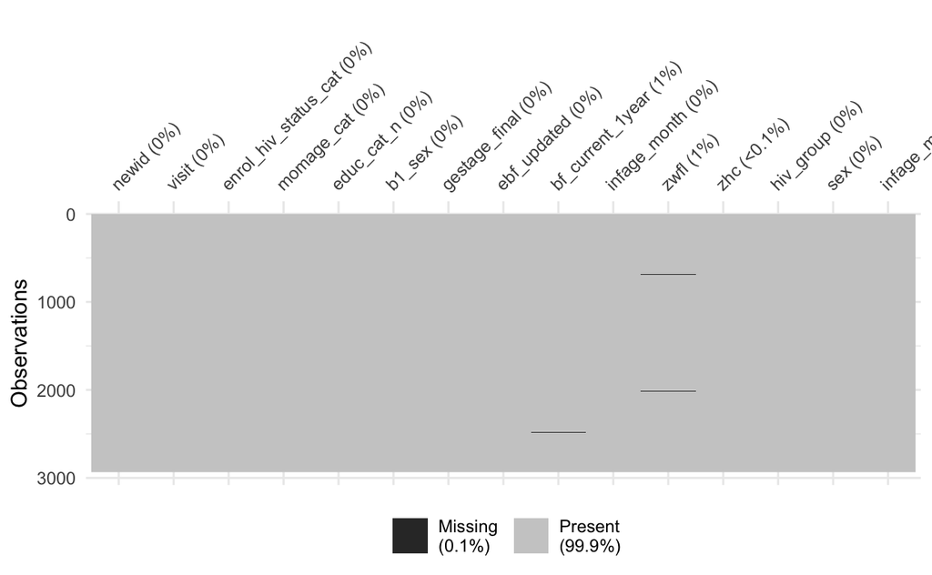

```r
vis_miss(analysis_dat)
```

# Analytic Dataset

```r
# Complete cases for all primary model variables.
# Excludes: 37 missing zwfl, 22 missing bf_current_1year, 5 missing ebf_updated.
main_dat <- analysis_dat |>
  filter(
    !is.na(zwfl),
    !is.na(hiv_group),
    !is.na(infage_month),
    !is.na(bf_current_1year),
    !is.na(ebf_updated),
    !is.na(sex)
  )
```

# Statistical Model

## Model Specification

We fit a **linear mixed effects model** (LME) to account for the correlation of repeated measures within each infant. The general model is:

$$Y_{ij} = \beta_0 + \beta_1 H_i + \beta_2
B_i + \beta_3 t^*_{ij} + \beta_4 S_i
+ \text{interactions} + u_i + \varepsilon_{ij}$$

where:

- $Y_{ij}$ = zwfl for infant $i$ at time $j$
- $H_i$ = HIV group (0 = CHU, 1 = CHEU)
- $B_i$ = breastfeeding status (0 = No, 1 = Yes)
- $t^*_{ij}$ = mean-centred age in months: $t^* = t - \bar{t}$
- $S_i$ = infant sex (0 = Female, 1 = Male)
- $u_i \sim \mathcal{N}(0, \sigma^2_u)$ = random intercept per infant
- $\varepsilon_{ij} \sim \mathcal{N}(0, \sigma^2)$ =s residual error

Mean-centring age improves optimizer convergence and makes $\beta_0$ interpretable as expected zwfl at the **mean observed age** rather than at birth.